# Fourth Week: Hypothesis Testing

TIMSS Analysis

??Ali Mohammad Faraji

2018-03-08 19:54:45

# loading data: library(dplyr) ## ## Attaching package: 'dplyr' ## The following objects are masked from 'package:stats': ## ## filter, lag ## The following objects are masked from 'package:base': ## ## intersect, setdiff, setequal, union library(ggplot2) bcg = readRDS("C:\\Users\\hoco\\Desktop\\data analysis\\hw_04\\DataAnalysis_data_hw4\\data\\bcg.rds") bsa = readRDS("C:\\Users\\hoco\\Desktop\\data analysis\\hw_04\\DataAnalysis_data_hw4\\data\\bsa.rds") bsg = readRDS("C:\\Users\\hoco\\Desktop\\data analysis\\hw_04\\DataAnalysis_data_hw4\\data\\bsg.rds") bsr = readRDS("C:\\Users\\hoco\\Desktop\\data analysis\\hw_04\\DataAnalysis_data_hw4\\data\\bsr.rds") bst = readRDS("C:\\Users\\hoco\\Desktop\\data analysis\\hw_04\\DataAnalysis_data_hw4\\data\\bst.rds") btm = readRDS("C:\\Users\\hoco\\Desktop\\data analysis\\hw_04\\DataAnalysis_data_hw4\\data\\btm.rds") bts = readRDS("C:\\Users\\hoco\\Desktop\\data analysis\\hw_04\\DataAnalysis_data_hw4\\data\\bts.rds") tims = readRDS("C:\\Users\\hoco\\Desktop\\data analysis\\hw_04\\DataAnalysis_data_hw4\\timss_2015.rds") merge(bts, bst, by.x = c("idcntry", "idschool", "itcourse", "idteach"), by.y = c("idcntry", "idschool", "itcourse", "idteach")) %>% select(idcntry, idschool, itcourse, idteach, idstud, bsmmat01, bsmmat02, bsmmat03, bsmmat04, bsmmat05, btbg10a, btbg10b, btbg10c, btbg10d, btbg10e, btbg10f, btbg10g) %>% rowwise() %>% mutate(goodInMath = mean(c(bsmmat01, bsmmat02, bsmmat03, bsmmat04, bsmmat05), na.rm = T)) %>% mutate(satisfaction = ifelse(btbg10b<3,1,0), na.rm = T) %>% select(goodInMath, satisfaction) -> satisfactionTeacher hypo_tTest = t.test(goodInMath~satisfaction , data = satisfactionTeacher) print(hypo_tTest) ## ## Welch Two Sample t-test ## ## data: goodInMath by satisfaction ## t = -39.875, df = 80464, p-value < 2.2e-16 ## alternative hypothesis: true difference in means is not equal to 0 ## 95 percent confidence interval: ## -19.20934 -17.40940 ## sample estimates: ## mean in group 0 mean in group 1 ## 471.7514 490.0608 ggplot(satisfactionTeacher, aes(satisfaction, goodInMath, group = satisfaction, fill = satisfaction)) + geom_boxplot() ## Warning: Removed 34038 rows containing non-finite values (stat_boxplot). according to P-value, they are not independent. bsg %>% select(idcntry, idschool, idstud, bsmmat01, bsmmat02, bsmmat03, bsmmat04, bsmmat05, bsbg07a, bsbg07b) %>% group_by(idcntry, idschool, idstud) %>% filter(bsbg07a <= 7 & bsbg07b <= 7) %>% summarise(parentsAc = mean(c(bsbg07a, bsbg07b), na.rm = T) , goodAtMath = mean(c(bsmmat01, bsmmat02 ,bsmmat03, bsmmat04, bsmmat05), na.rm = T)) -> parentsAcademic parentsAcademic %>% mutate(newAc = ifelse(parentsAc > 4, 1, 0)) -> parentsAcademicCateg t.test(goodAtMath~newAc, data = parentsAcademicCateg) -> parentsActTest print(parentsActTest) ## ## Welch Two Sample t-test ## ## data: goodAtMath by newAc ## t = -137.16, df = 162200, p-value < 2.2e-16 ## alternative hypothesis: true difference in means is not equal to 0 ## 95 percent confidence interval: ## -69.69317 -67.72948 ## sample estimates: ## mean in group 0 mean in group 1 ## 453.7064 522.4177 ggplot(parentsAcademicCateg, aes(newAc, goodAtMath, group = newAc, fill = newAc)) + geom_boxplot() according to P-value, they are not independent. bsg %>% select(idcntry, idschool, idstud, bsmmat01, bsmmat02, bsmmat03, bsmmat04, bsmmat05, bsbg06a, bsbg06b, bsbg06c, bsbg06d, bsbg06e, bsbg06f, bsbg06g) %>% group_by(idcntry, idschool, idstud) %>% summarise(goodAtMath = mean(c(bsmmat01, bsmmat02, bsmmat03, bsmmat04, bsmmat05), na.rm = T), refahi = mean(c(bsbg06a,bsbg06b, bsbg06c, bsbg06d, bsbg06e, bsbg06f, bsbg06g))) %>% rowwise() %>% mutate(refahi2 = ifelse(refahi < 1.5, 1, 0)) -> refahi3 aov(goodAtMath ~ refahi2, data = refahi3) -> aov3 print(summary.aov(aov3)) ## Df Sum Sq Mean Sq F value Pr(>F) ## refahi2 1 2.206e+08 220552054 21702 <2e-16 *** ## Residuals 262559 2.668e+09 10163 ## --- ## Signif. codes: 0 '***' 0.001 '**' 0.01 '*' 0.05 '.' 0.1 ' ' 1 ## 17569 observations deleted due to missingness ggplot(refahi3, aes(refahi2, goodAtMath, group = refahi2, fill = refahi2)) + geom_boxplot() ## Warning: Removed 17569 rows containing non-finite values (stat_boxplot). according to P-value and the plot, the statement is true. merge(bts, bst, by.x = c("idcntry", "idschool", "itcourse", "idteach"), by.y = c("idcntry", "idschool", "itcourse", "idteach")) %>% select(idcntry, idschool, itcourse, idteach, idstud, bsmmat01, bsmmat02, bsmmat03, bsmmat04, bsmmat05, btbg07b) %>% rowwise() %>% mutate(goodAtMath = mean(c(bsmmat01, bsmmat02, bsmmat03, bsmmat04, bsmmat05), na.rm = T)) %>% select(goodAtMath, safety = btbg07b) -> mohitAram aov(goodAtMath ~ safety, data = mohitAram) -> aov4 print(summary.aov(aov4)) ## Df Sum Sq Mean Sq F value Pr(>F) ## safety 1 1.101e+08 110128028 10896 <2e-16 *** ## Residuals 448211 4.530e+09 10108 ## --- ## Signif. codes: 0 '***' 0.001 '**' 0.01 '*' 0.05 '.' 0.1 ' ' 1 ## 32609 observations deleted due to missingness ggplot(mohitAram, aes(safety, goodAtMath, group = safety, fill = safety)) + geom_boxplot() ## Warning: Removed 32609 rows containing non-finite values (stat_boxplot). according to P-value and the plot, the statement is true. bsg %>% select(bsbg12, idcntry, idschool, idstud, bsmmat01, bsmmat02, bsmmat03, bsmmat04, bsmmat05) %>% group_by(idcntry, idschool, idstud) %>% summarise(eat = mean(bsbg12) , goodAtMath = mean(c(bsmmat01, bsmmat02 ,bsmmat03, bsmmat04, bsmmat05), na.rm = T)) -> eat7 aovEat = aov(goodAtMath ~ eat, data = eat7) print(summary.aov(aovEat)) ## Df Sum Sq Mean Sq F value Pr(>F) ## eat 1 3.265e+07 32653399 2940 <2e-16 *** ## Residuals 276078 3.066e+09 11105 ## --- ## Signif. codes: 0 '***' 0.001 '**' 0.01 '*' 0.05 '.' 0.1 ' ' 1 ## 4050 observations deleted due to missingness ggplot(eat7, aes(eat, goodAtMath, fill = eat, group = eat)) + geom_boxplot() ## Warning: Removed 4050 rows containing non-finite values (stat_boxplot). according to P-value and the plot, the statement is true. bsg %>% select(idcntry, idschool, idstud, bsmmat01, bsmmat02, bsmmat03, bsmmat04, bsmmat05, bsbg11) %>% group_by(idcntry, idschool, idstud) %>% summarise(presence = mean(bsbg11) , goodAtMath = mean(c(bsmmat01, bsmmat02 ,bsmmat03, bsmmat04, bsmmat05), na.rm = T)) -> studentPresence aovPresence = aov(goodAtMath ~ presence, data = studentPresence) print(summary.aov(aovPresence)) ## Df Sum Sq Mean Sq F value Pr(>F) ## presence 1 2.648e+08 264849314 25650 <2e-16 *** ## Residuals 264983 2.736e+09 10326 ## --- ## Signif. codes: 0 '***' 0.001 '**' 0.01 '*' 0.05 '.' 0.1 ' ' 1 ## 15145 observations deleted due to missingness ggplot(studentPresence, aes(presence, goodAtMath, fill = presence, group = presence)) + geom_boxplot() ## Warning: Removed 15145 rows containing non-finite values (stat_boxplot). according to P-value and the plot, the statement is true. tims %>% filter(Country == "Iran, Islamic Rep. of") %>% filter(cognitive_domain == "Applying" | cognitive_domain == "Reasoning") -> Iran10 aov(correct_ratio_per_question~cognitive_domain, data = Iran10) -> aov10 print(summary.aov(aov10)) ## Df Sum Sq Mean Sq F value Pr(>F) ## cognitive_domain 1 0.1493 0.14927 6.9 0.00958 ** ## Residuals 139 3.0068 0.02163 ## --- ## Signif. codes: 0 '***' 0.001 '**' 0.01 '*' 0.05 '.' 0.1 ' ' 1 ggplot(Iran10, aes(cognitive_domain, correct_ratio_per_question, group = cognitive_domain, fill = cognitive_domain)) + geom_boxplot() according to P-value and the plot, the statement is not true. In fact Iranian students are better in Applying than Reasoning.

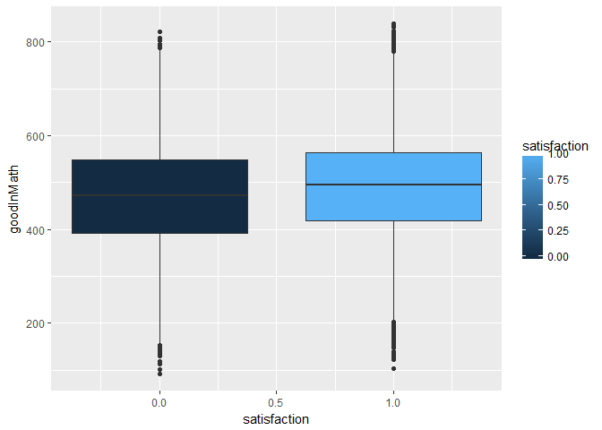

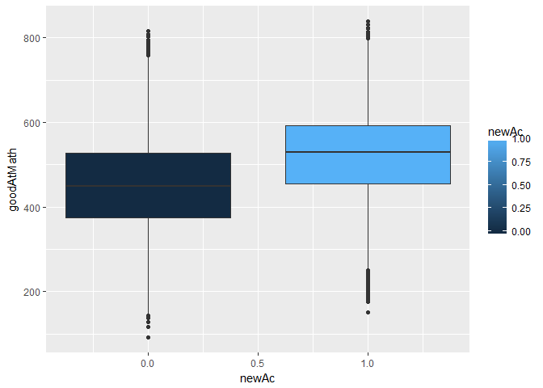

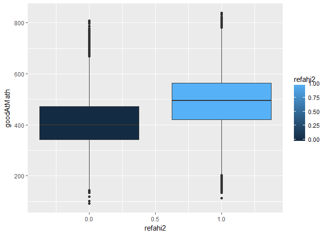

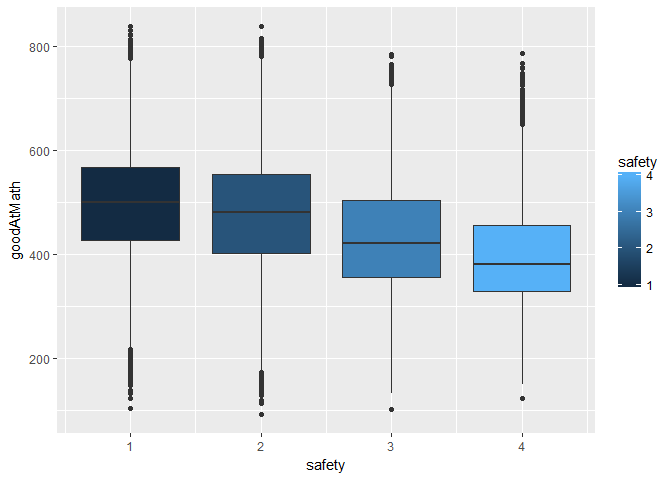

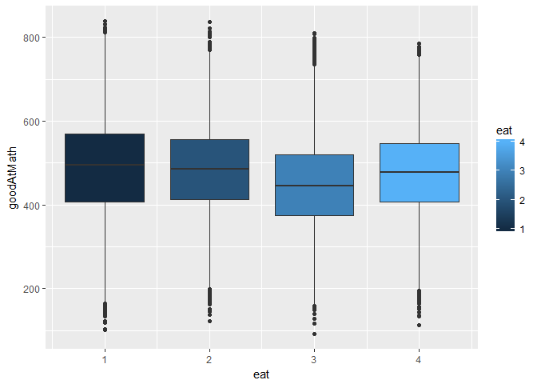

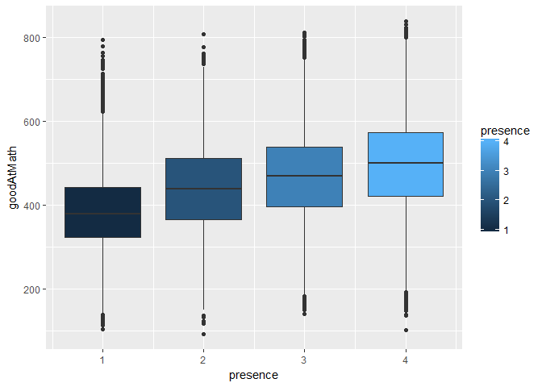

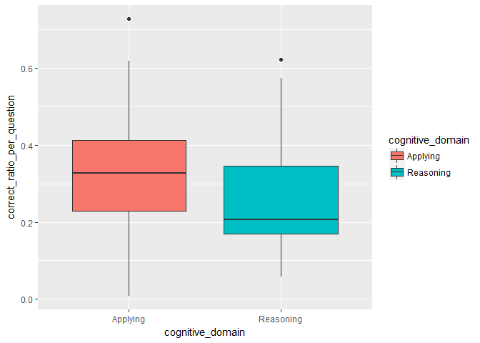